# Homework 10

Arlette Hall

2026-02-12

## Instructions

Answer the following questions and complete the exercises in RMarkdown. Please embed all of your code and push your final work to your repository. Your final lab report should be organized, clean, and run free from errors. Remember, you must remove the `#` for the included code chunks to run. Be sure to add your name to the author header above.

Make sure to use the formatting conventions of RMarkdown to make your report neat and clean!

## Background

In the `data` folder, you will find data about shark incidents in California between 1950-2022. The [data](https://catalog.data.gov/dataset/shark-incident-database-california-56167) are from: State of California- Shark Incident Database.

## Load the libraries

```r
library("tidyverse")
library("janitor")
```

## Load the data

Run the following code chunk to import the data. In this chunk, I am removing NA’s.

```r
sharks <-
  read_csv("data/SharkIncidents_1950_2022_220302.csv",
           na=c("NA", "N/A", "Unknown", "NOT COUNTED", "", " ")) %>%
  clean_names()
```

## Questions

1. Are there any “hotspots” for shark incidents in California? Show the top five counties with the most incidents.

```r
sharks %>%
  group_by(county) %>%
  summarize(n_incidents = n()) %>%
  slice_max(n_incidents, n=5)
```

```
## # A tibble: 6 × 2
##   county        n_incidents
##   <chr>               <int>
## 1 San Diego              25
## 2 Humboldt               20
## 3 San Mateo              19
## 4 Santa Barbara          19
## 5 Marin                  16
## 6 Monterey               16
```

2. Make a plot that shows the total number of incidents per county.

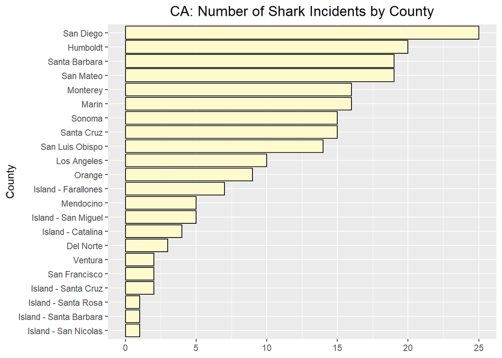

```r
sharks %>%
  group_by(county) %>%
  summarize(n = n()) %>%
  ggplot(mapping=aes(x=reorder(county, n), y=n))+
  geom_col(color="black", fill="lemonchiffon", na.rm=T)+
  coord_flip()+
  labs(x="County", y=NULL, title="CA: Number of Shark Incidents by County")+
  theme(plot.title=element_text(size=rel(1.3), hjust=0.5))
```

3. Are there months of the year when incidents are more likely to occur? Make a plot that shows the total number of incidents by month. Which month has the highest number of incidents?

```r
sharks %>%
  group_by(month) %>%
  summarize(n_incidents = n()) %>%
  arrange(desc(n_incidents))
```

```
## # A tibble: 12 × 2
##    month n_incidents
##    <dbl>       <int>
##  1    10          36
##  2     9          34
##  3     8          31
##  4     7          27
##  5     5          16
##  6    11          16
##  7     6          14
##  8    12          13
##  9     1           8
## 10     4           7
## 11     3           5
## 12     2           4
```

```r
#Yes, there are months when incidents are more likely to occur.
```

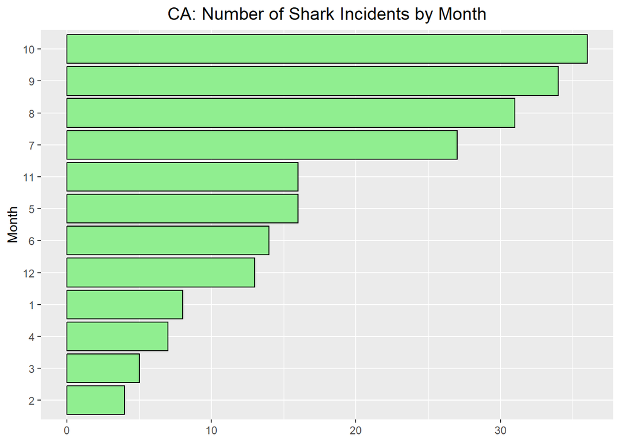

```r
sharks %>%
  group_by(month) %>%
  summarize(n = n()) %>%
  ggplot(mapping=aes(x=reorder(month, n), y=n))+
  geom_col(color="black", fill="lightgreen", na.rm=T)+
  coord_flip()+
  labs(x="Month", y=NULL, title="CA: Number of Shark Incidents by Month")+
  theme(plot.title=element_text(size=rel(1.3), hjust=0.5))
```

```r
#October has the highest number of shark incidents.
```

4. Is there a time of day when most attacks occur? Make a plot that shows the total number of incidents by time of day. Which time of day has the highest number of incidents?

```r
sharks %>%
  filter(time != "NA") %>%
  group_by(time) %>%
  summarize(n_incidents = n()) %>%
  slice_max(n_incidents)
```

```
## # A tibble: 1 × 2
##   time  n_incidents
##   <chr>       <int>
## 1 11:00          18
```

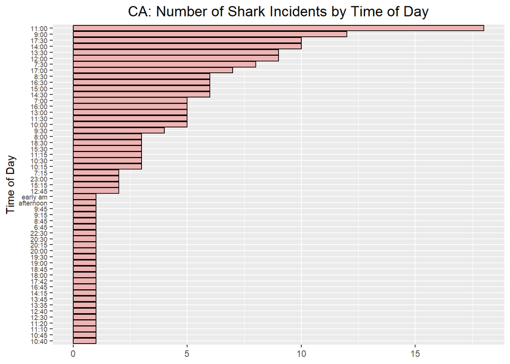

```r
sharks %>%
  filter(time != "NA") %>%
  group_by(time) %>%
  summarize(n = n()) %>%
  ggplot(mapping=aes(x=reorder(time, n), y=n))+
  geom_col(color="black", fill="rosybrown2", na.rm=T)+
  labs(x="Time of Day",
       y=NULL,
       title="CA: Number of Shark Incidents by Time of Day")+
  coord_flip()+
  theme(plot.title=element_text(size=rel(1.3), hjust=0.5),
        axis.text.y=element_text(size=rel(0.75)))
```

```r
#11:00 a.m. is most common for shark attacks.
```

5. How do the number and types of injuries compare by county? Make a table that shows the number of injury types by county. Which county has the highest number incidents? (hint: your table should be in wide format)

```r
#Number of injury types by county
sharks %>%
  group_by(county) %>%
  summarize(n_injury_types = n_distinct(injury, na.rm=T)) %>%
  arrange(desc(n_injury_types))
```

```
## # A tibble: 22 × 2
##    county              n_injury_types
##    <chr>                        <int>
##  1 San Diego                        6
##  2 Humboldt                         5
##  3 Monterey                         5
##  4 San Mateo                        5
##  5 Los Angeles                      4
##  6 Orange                           4
##  7 San Luis Obispo                  4
##  8 Santa Barbara                    4
##  9 Santa Cruz                       4
## 10 Island - San Miguel              3
## # ℹ 12 more rows
```